# YoTube Sensation

## Introduction

Go to the app store on your phone and try to find an app to watch videos and YouTube surfaces as the top-rated. YouTube is the most popular app and website to watch any video. I often share YouTube videos on lawn care and planting gardens. YouTube is an American video-sharing website with headquartes in San Bruno, California. Chad Hurley, Steve Chen, and Jawed Karim founded YouTube in February 2005. Google bought the site in November 2006 for US$1.65 billion, and now the largely branded company operates as one of Google’s affiliates. YouTube allows you to explore new content, music, news, and more through an official app or the website. Subscribing to particular channels that house the users favorite content, sharing videos with friends, or uploading videos for public scrutiny are some significant features of YouTube.

YouTube most popular videos are labeled as “trending.” Trending helps viewers to see the top news, events, and miscellaneous situations in the video world. Trending videos are collected primarily when a wide range of viewers would find interesting. Some trends are predictable, like a new song from a famous artist or a new movie trailer. Others are surprising, like a viral video. Trending is not personalized and displays the same list of trending videos in each country to all user. The list of trending videos is updated roughly every 15 minutes. With each update, videos may move up, down, but rarely stay in the same position in the list. YouTube maintains a list of the top trending videos. YouTube uses a combination of factors, including measuring the number of views, shares, comments, and likes to make the commercials and determine trending videos.

This dataset is a daily record of the top trending YouTube videos and the factors that influences them. Analyzing this dataset, we look at the main factors that are included in making the videos trending such as likes, dislikes, and comments. We can view what is needed to make a video be on the trending list. To analyze this data plan is to use linear regression with the variables likes, dislike, comments, and names. The deliverable will be a poster.

The data set that used comes from kaggle.com the original data set has 40,881 observations and 14 variables. This data set includes trending videos in 2017 and 2018. Since I want to become a YouTube personality, I explore information regarding how videos start to trend. Evaluating, the likes, dislikes, views, and comments, the data set seems to have valuable information. This capstone project encompasses all of the techniques that were learned in this course. It begins with the data wrangling process - the process of cleaning the data set. Exploratory data analysis is the next section of the project. It includes the inferential knowledge that leads to selecting the independent and dependent variables. In the machine learning section, linear regression models are built to predict the number of views necessary for a video to trend. The results are noted, and future work is described.

We aim to help YouTube to provide users with a threshold so they can know precisely know what is expected for views, likes, dislikes and comments for their video to be considered as a trending video. The information gathered and presented provides clear cut information to users. It also will help YouTube to determine the YouTube channel that they can use for advertisement purposes.

The First step in for any project is to install and load the necessary packages by declaring the libraries. The plyr package is to be used to select the variables in the clean data and the tidy verse for most of the other functions. Tidyverse is considered the swiss knife because of its unlimited capabilities. All packages used in the data wrangling process and the statistics are loaded into the console.

```r
library(tidyverse) #The swiss knife!
```

```r
library(ggplot2)
library(rmarkdown)
library(dplyr)
library(tidyr)
library(knitr)
library(caret)
```

To begin the cleaning process, we take a peek at the working directory with the getwd() function. If the working directory is not set to read the files, then the working directory has to be changed. The working directory is confirmed, and the data is imported.

```r
getwd()
```

```
## [1] "F:/Lopez"
```

```r
df <- read.csv("YouTube.csv")
```

```r
str(df)
```

```
## 'data.frame':    40881 obs. of  14 variables:
##  $ video_id              : Factor w/ 24104 levels "--45ws7CEN0",..: 14219 586 2731 6677 1594 847 387 1465 11920 2086 ...
##  $ trending_date         : Factor w/ 205 levels "17.01.12","17.02.12",..: 14 14 14 14 14 14 14 14 14 14 ...
##  $ title                 : Factor w/ 24573 levels "''Gala Artis 2018'' Le numÃ©ro d'ouverture",..: 7886 16653 17304 10553 7746 11410 22920 23362 20575 8523 ...
##  $ channel_title         : Factor w/ 5076 levels "- æ¬¢è¿Žè®¢é\230… -æµ\231æ±Ÿå\215«è§†ã\200\220å¥”è·‘å\220§ã\200‘å®\230æ–¹é¢‘é\201“",..: 1430 2067 3755 3216 1391 1304 4767 810 2675 3905 ...
##  $ category_id           : int  10 23 23 24 10 25 23 22 24 22 ...
##  $ publish_time          : Factor w/ 23613 levels "2008-01-13T01:32:16.000Z",..: 68 260 180 172 55 228 205 265 188 64 ...
##  $ tags                  : Factor w/ 20157 levels "''Hace|\"minuto''\"|\"''hace\"|\"minutos''\"|\"''MÃ¡quinas''\"|\"''animales''\"|\"''mejores''\"|\"tops''\"|\"''"| __truncated__,..: 5897 13838 14461 15239 5761 19 6961 15782 11002 7337 ...
##  $ views                 : int  17158579 1014651 3191434 2095828 33523622 1309699 2987945 748374 4477587 505161 ...
##  $ likes                 : int  787425 127794 146035 132239 1634130 103755 187464 57534 292837 4135 ...
##  $ dislikes              : int  43420 1688 5339 1989 21082 4613 9850 2967 4123 976 ...
##  $ comment_count         : int  125882 13030 8181 17518 85067 12143 26629 15959 36391 1484 ...
##  $ comments_disabled     : logi  FALSE FALSE FALSE FALSE FALSE FALSE ...
##  $ ratings_disabled      : logi  FALSE FALSE FALSE FALSE FALSE FALSE ...
##  $ video_error_or_removed: logi  FALSE FALSE FALSE FALSE FALSE FALSE ...
```

The view function gives a table of all observations and variables. Some of the variables were easier to understand than others. The varialbes such as likes, dislikes, comment count, and views were plainly understood. The other variables did not have units specified, which makes it hard to interpret. There are missing variables in the data set labeled as NA. Let’s take a glimpse of the data set.

The glimpse function provides more concise information regarding the data set. A glimpse of the data set is called to determine the type of variables and ensure that the data set is correct.

```r
glimpse(df)
```

```
## Observations: 40,881
## Variables: 14
## $ video_id               <fct> n1WpP7iowLc, 0dBIkQ4Mz1M, 5qpjK5DgCt4, ...
## $ trending_date          <fct> 17.14.11, 17.14.11, 17.14.11, 17.14.11,...
## $ title                  <fct> "Eminem - Walk On Water (Audio) ft. Bey...
## $ channel_title          <fct> EminemVEVO, iDubbbzTV, Rudy Mancuso, ni...
## $ category_id            <int> 10, 23, 23, 24, 10, 25, 23, 22, 24, 22,...
## $ publish_time           <fct> 2017-11-10T17:00:03.000Z, 2017-11-13T17...
## $ tags                   <fct> Eminem|"Walk"|"On"|"Water"|"Aftermath/S...
## $ views                  <int> 17158579, 1014651, 3191434, 2095828, 33...
## $ likes                  <int> 787425, 127794, 146035, 132239, 1634130...
## $ dislikes               <int> 43420, 1688, 5339, 1989, 21082, 4613, 9...
## $ comment_count          <int> 125882, 13030, 8181, 17518, 85067, 1214...
## $ comments_disabled      <lgl> FALSE, FALSE, FALSE, FALSE, FALSE, FALS...
## $ ratings_disabled       <lgl> FALSE, FALSE, FALSE, FALSE, FALSE, FALS...
## $ video_error_or_removed <lgl> FALSE, FALSE, FALSE, FALSE, FALSE, FALS...
```

The table shows that there is 14 variables and 40,881 observations. The variables are labelled as factor,integer, and lgl.

## Data Wrangling

Data wrangling is one of the most essential parts of a data science project. Data wrangling is the process of mapping data from raw to a format appropriate for the data to be analyzed. Data wrangling consists of selecting, indexing, and mutating the tables to form them for your need. This process helps with better decision making, but it takes a long time to complete. If it is done correctly, then a data scientist life is made easier. These steps will help to deliver more accurate results. The data used contained 14 variables and 40,881 observations. They are multiple techniques used to clean and conform the data before the analysis. The packages have been loaded in a previous code chunk. The loaded packages allow syntax that is simple to use when cleaning the data. The first step is to remove unnecessary variables which are the columns of the data set. Once the columns are removed, the data set is reviewed using the glimpse function.

```r
df <- df[c(-1,-4,-5,-6,-7,-12,-13,-14)]
glimpse(df)
```

```
## Observations: 40,881
## Variables: 6
## $ trending_date <fct> 17.14.11, 17.14.11, 17.14.11, 17.14.11, 17.14.11...
## $ title         <fct> "Eminem - Walk On Water (Audio) ft. BeyoncÃ©", "...
## $ views         <int> 17158579, 1014651, 3191434, 2095828, 33523622, 1...
## $ likes         <int> 787425, 127794, 146035, 132239, 1634130, 103755,...
## $ dislikes      <int> 43420, 1688, 5339, 1989, 21082, 4613, 9850, 2967...
## $ comment_count <int> 125882, 13030, 8181, 17518, 85067, 12143, 26629,...
```

```r
nrow(df)
```

```
## [1] 40881
```

The table shows that there is 6 variables and 40,881 observations. The variables are labelled as factor and integer. By removing insignificant variables from the data frame, the new data set contains the variables trending date, title likes, view, dislikes, and comment count. Theses variable provides information pertinent information regarding the trending videos.

Since the data set already comprises only trending videos, and that the likelihood of observing a trending video, opened for comments, receiving zero comments is minimal. This may no be the best way to handle this situation but it is a way.

```r
df[df == 0] <- NA
df <- na.omit(df)
glimpse(df)
```

```
## Observations: 39,924
## Variables: 6
## $ trending_date <fct> 17.14.11, 17.14.11, 17.14.11, 17.14.11, 17.14.11...
## $ title         <fct> "Eminem - Walk On Water (Audio) ft. BeyoncÃ©", "...
## $ views         <int> 17158579, 1014651, 3191434, 2095828, 33523622, 1...
## $ likes         <int> 787425, 127794, 146035, 132239, 1634130, 103755,...
## $ dislikes      <int> 43420, 1688, 5339, 1989, 21082, 4613, 9850, 2967...
## $ comment_count <int> 125882, 13030, 8181, 17518, 85067, 12143, 26629,...
```

Since the missing data values have been deleted the number of observations are minimized. The table shows that there is 6 variables and 39,924 observations. The variables types are factor and integer. The data is numerical. Thus we look at a summary of the data.

```r
mean(df$views)
```

```
## [1] 1153527
```

```r
summary(df$views)
```

```
##      Min.   1st Qu.    Median      Mean   3rd Qu.      Max.
##      1023    148818    377166   1153527    970374 137843120
```

The mean number of views is 1,153,527. The clean data set is df and will be used for the remainder of the project.

## Dealing with Outliers

```r
df_1<-df %>% filter(views>=148818)
glimpse(df_1)
```

```
## Observations: 29,943
## Variables: 6
## $ trending_date <fct> 17.14.11, 17.14.11, 17.14.11, 17.14.11, 17.14.11...
## $ title         <fct> "Eminem - Walk On Water (Audio) ft. BeyoncÃ©", "...
## $ views         <int> 17158579, 1014651, 3191434, 2095828, 33523622, 1...
## $ likes         <int> 787425, 127794, 146035, 132239, 1634130, 103755,...
## $ dislikes      <int> 43420, 1688, 5339, 1989, 21082, 4613, 9850, 2967...
## $ comment_count <int> 125882, 13030, 8181, 17518, 85067, 12143, 26629,...
```

The table shows that the data set df_1 has 6 variables and 29,943 observations. Let’s take a look at the summary of df_1 to view the changes in the mean number of views.

```r
summary(df_1$views)
```

```
##      Min.   1st Qu.    Median      Mean   3rd Qu.      Max.
##    148823    304129    586076   1512629   1325222 137843120
```

There is evidence that some trending videos are more popular than others. A popularity index is created to distinguish between highly trending and trending videos based on the number of views. The threshold is selected to be 586,076 the medeian number of views.

```r
df_1$Popularity_Index <- ifelse(( df_1$views >= 586076), '1', '0')
```

We take one last look at the clean data set and write it to the console.

```r
glimpse(df_1)
```

```
## Observations: 29,943
## Variables: 7
## $ trending_date    <fct> 17.14.11, 17.14.11, 17.14.11, 17.14.11, 17.14...
## $ title            <fct> "Eminem - Walk On Water (Audio) ft. BeyoncÃ©"...
## $ views            <int> 17158579, 1014651, 3191434, 2095828, 33523622...
## $ likes            <int> 787425, 127794, 146035, 132239, 1634130, 1037...
## $ dislikes         <int> 43420, 1688, 5339, 1989, 21082, 4613, 9850, 2...
## $ comment_count    <int> 125882, 13030, 8181, 17518, 85067, 12143, 266...
## $ Popularity_Index <chr> "1", "1", "1", "1", "1", "1", "1", "1", "1", ...
```

```r
write.csv(df_1, file = "df_1clean.csv")
```

## Statistical Analysis

Now that the data set is cleaned, it is time for the statistical analysis. This analysis is the exploratory portion of the project. At this time, we are trying to find trends in the project data based on the facts and develop a solid hypothesis. In this portion of the coding in R, plots are created and analyzed. A deep analysis of the trending videos is investigated.

When reading in the data file, an additional variable appears. That variable is removed. A glimpse of the data set is called to determine the type of variables and ensure that the data set is correct.

```r
glimpse(df)
```

```
## Observations: 39,924
## Variables: 6
## $ trending_date <fct> 17.14.11, 17.14.11, 17.14.11, 17.14.11, 17.14.11...
## $ title         <fct> "Eminem - Walk On Water (Audio) ft. BeyoncÃ©", "...
## $ views         <int> 17158579, 1014651, 3191434, 2095828, 33523622, 1...
## $ likes         <int> 787425, 127794, 146035, 132239, 1634130, 103755,...
## $ dislikes      <int> 43420, 1688, 5339, 1989, 21082, 4613, 9850, 2967...
## $ comment_count <int> 125882, 13030, 8181, 17518, 85067, 12143, 26629,...
```

Since there is an enormous amount of data for trending videos, the means of each variable is explored. The code to find the means is written below.

```r
daily_means <- df  %>%
  group_by(trending_date) %>%
  summarise(n_title = n(),
            mean_likes = mean(likes),
             mean_views = mean(views),
             mean_dislikes = mean(dislikes),
            mean_comment_count = mean(comment_count))
daily_means
```

```
## # A tibble: 205 x 6
##    trending_date n_title mean_likes mean_views mean_dislikes
##    <fct>           <int>      <dbl>      <dbl>         <dbl>
##  1 17.01.12          195     41083.   1134989.         2162.
##  2 17.02.12          196     52468.   1239664.         1813.
##  3 17.03.12          194     60609.   1531996.         2225.
##  4 17.04.12          193     63517.   1793375.         2683.
##  5 17.05.12          190     64213.   1829766.         2548.
##  6 17.06.12          192     51453.   1488403.         1552.
##  7 17.07.12          192     55936.   1760302.         4232.
##  8 17.08.12          196     36736.   1206701.         5980.
##  9 17.09.12          196     49789.   1598892.         7652.
## 10 17.10.12          198     50658.   1542022.         8214.
## # ... with 195 more rows, and 1 more variable: mean_comment_count <dbl>
```

The mean for the variables, likes, dislikes, views, and comment_count is collect for each trending date. The table also shows the number of videos per date. A graphical analysis of the means is annotated in the code below. We conduct this anlysis as it reduces the number of data points and patterns can be seen.

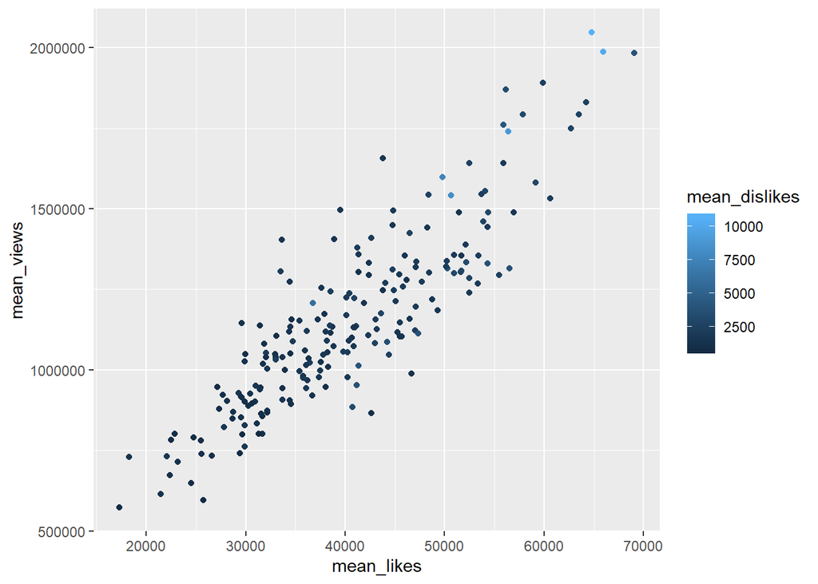

```r
ggplot(daily_means, aes(y = mean_views, x = mean_likes, color=mean_dislikes)) + geom_point()
```

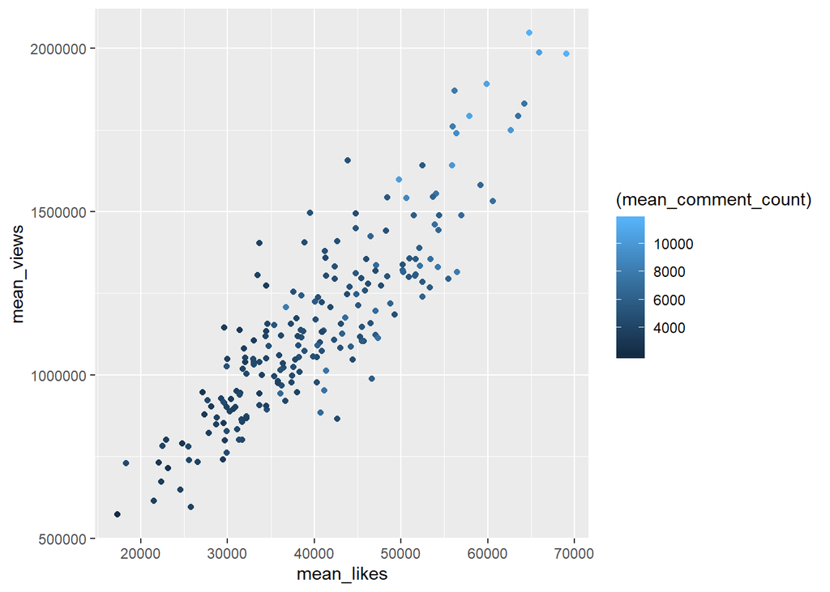

```r
ggplot(daily_means, aes(y = mean_views, x = mean_likes, color=(mean_comment_count))) + geom_point()
```

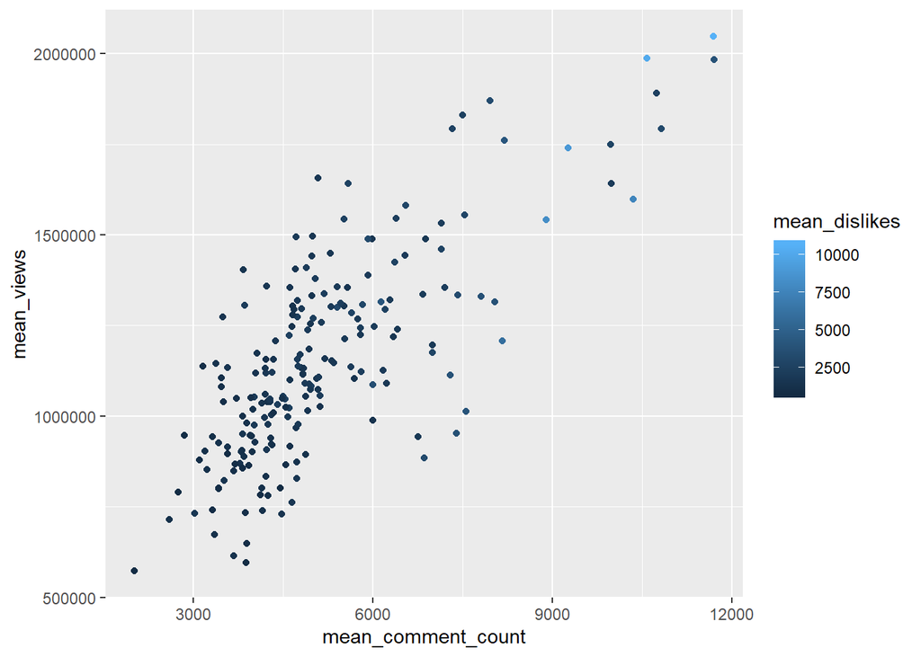

```r
ggplot(daily_means, aes(y = mean_views, x = mean_comment_count,  color=mean_dislikes)) + geom_point()
```

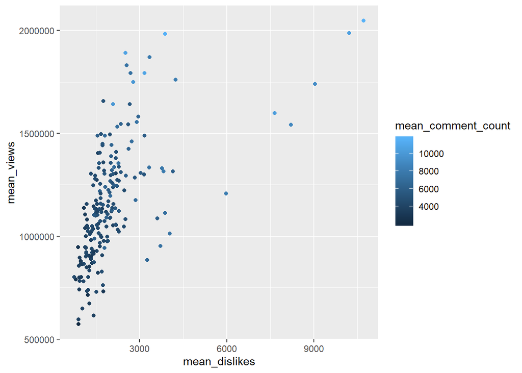

```r
ggplot(daily_means, aes(y = mean_views, x = mean_dislikes,color=mean_comment_count)) + geom_point()
```

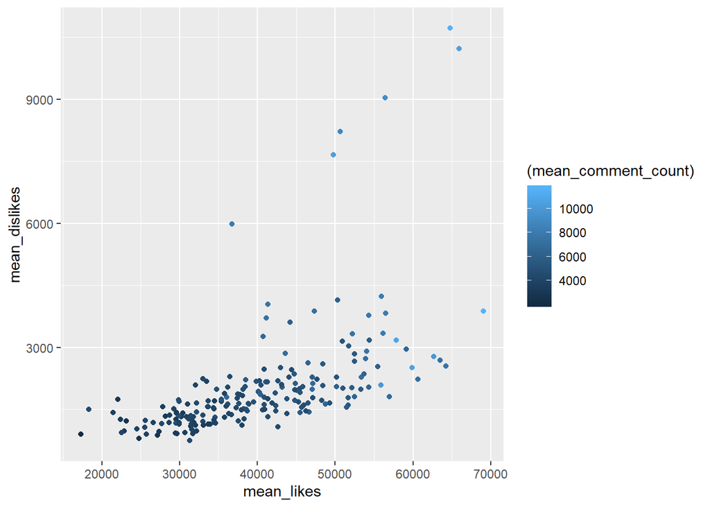

```r
ggplot(daily_means, aes(y = mean_dislikes, x = mean_likes, color=(mean_comment_count))) + geom_point()
```

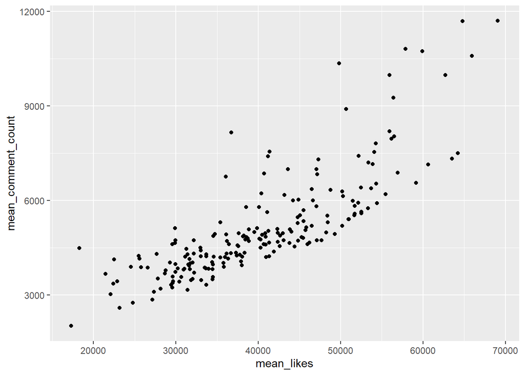

```r
ggplot(daily_means, aes(x =mean_likes , y = mean_comment_count, )) + geom_point()
```

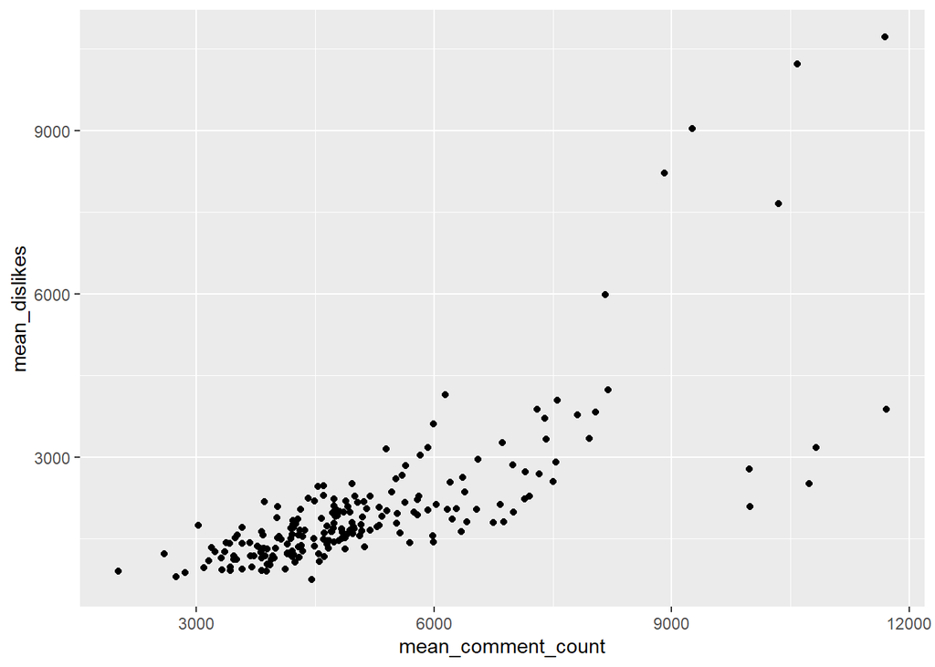

```r
ggplot(daily_means, aes(y = mean_dislikes, x =mean_comment_count , )) + geom_point()
```

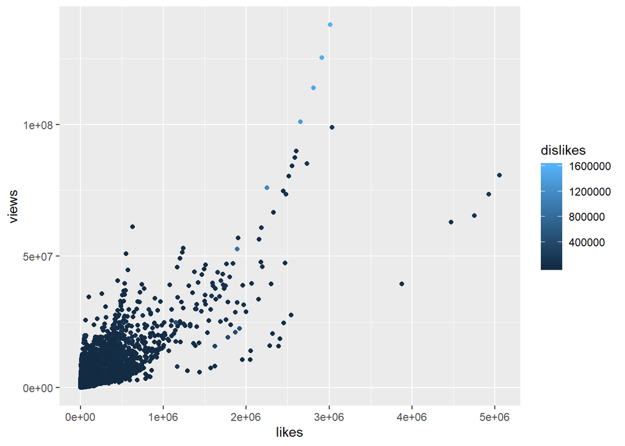

```r
ggplot(df, aes(y = views, x = likes, color=dislikes)) + geom_point()
```

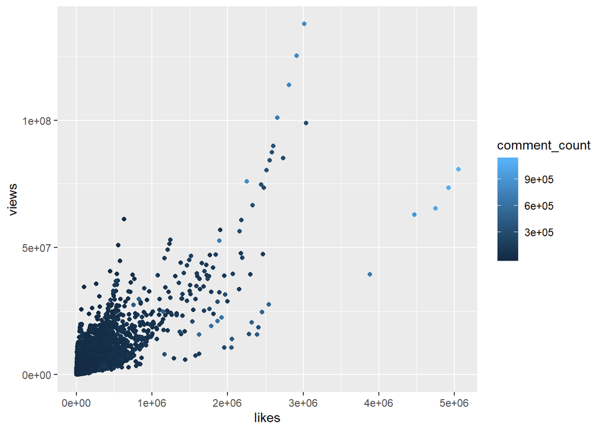

```r
ggplot(df, aes(y = views, x = likes, color=comment_count)) + geom_point()
```

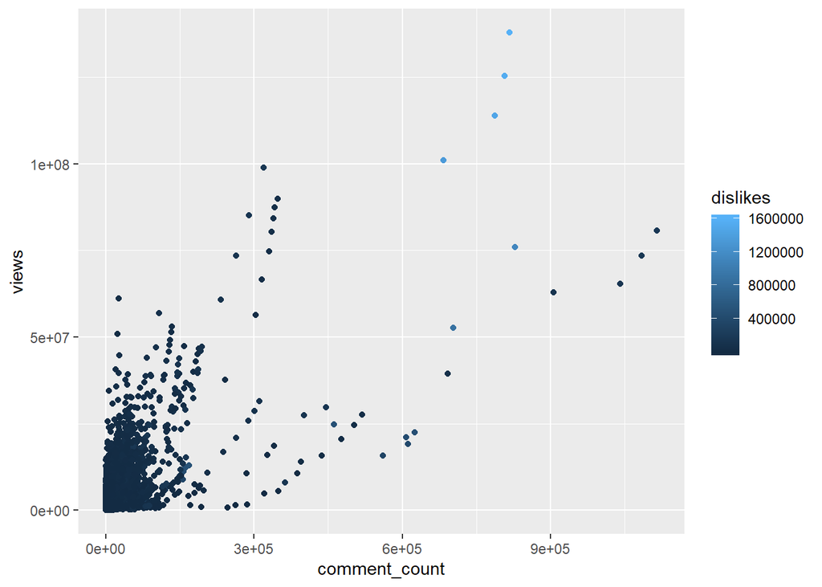

```r
ggplot(df, aes(y = views, x = comment_count, color=dislikes)) + geom_point()
```

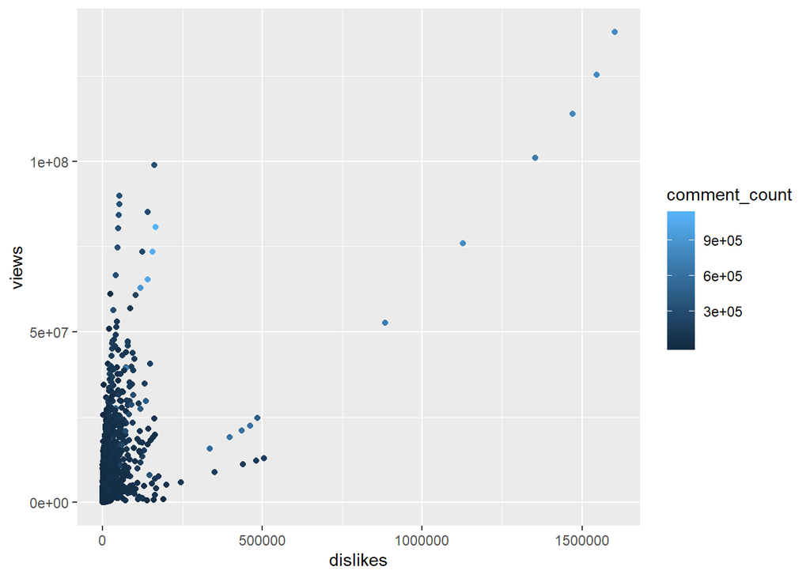

```r
ggplot(df, aes(y = views, x = dislikes, color=comment_count)) + geom_point()
```

Let’s take a look at the Popularity_Index variable that was created. I can remove this if you like.

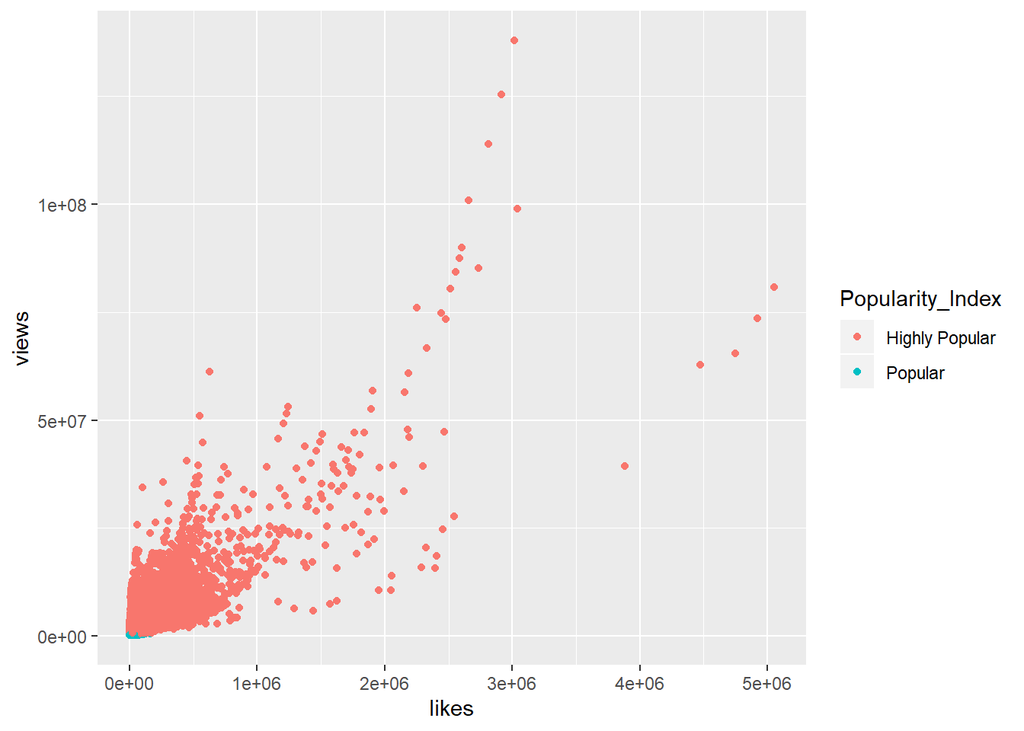

```r
df_1$Popularity_Index <- ifelse(df_1$Popularity_Index == 1, 'Highly Popular', 'Popular')
ggplot(df_1, aes(x = likes, y = views, color=Popularity_Index)) +
  geom_point()
```

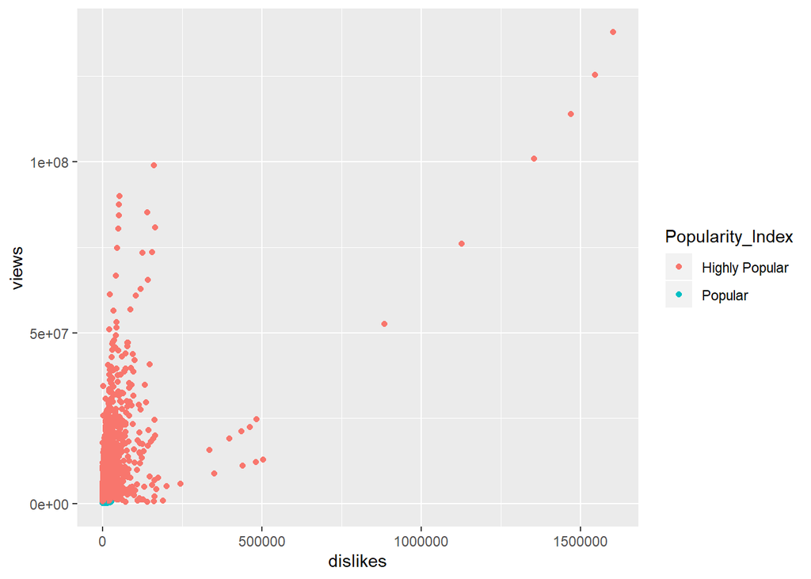

```r
ggplot(df_1, aes(x = dislikes, y = views, color=Popularity_Index)) +
  geom_point()
```

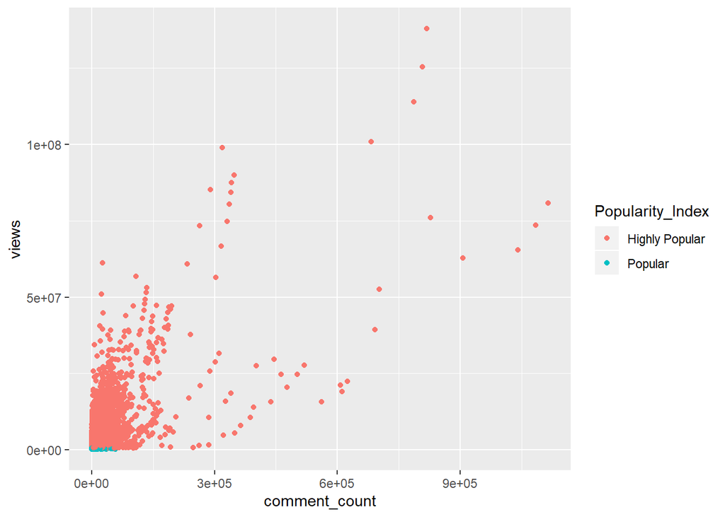

```r
ggplot(df_1, aes(x = comment_count, y = views, color=Popularity_Index)) +
  geom_point()
```

```r
write.csv(daily_means, file = "daily_means.csv")
```

## Machine Learning

The plots created, and a clearer understanding of the data set has been achieved. The models below explores the relationship between the dependent variables and the independent variables. After creating multiple models, we conclude that the model of best fit has a dependent variable is views, and the independent variables are likes, dislikes, and comments. Since the dependent variable is a numerical value, multiple linear regression will be used as the machine learning technique.For the machine learning portion of the capstone project, the number of views is predicted given the number of likes, dislikes, and comments.

Before the linear model is created, the data is divided into testing and training data. The divide used is 80% to train the model and 20% of the data to test the model. To determine if the model of best fit is a good model the metrics R-squared RMSE, and p-value are observed. The model is built using the original data and not the daily means of the the data. The code below splits the data set. Set seed gives a starting point for splitting the data.

```r
set.seed(7)
validation_index <- createDataPartition(df$views, p=0.80, list=FALSE)
testing <- df[-validation_index,]
# use the remaining 80% of data to training and testing the models
training <- df[validation_index,]
```

## Model1

In model1, the dependent variable is views, and the dependent variable is dislikes. The independent variable is statistically significant but $R^2$ is only 0.3384. We can produce a better model.

```r
model1 <- lm(views ~ dislikes, likes , data = training)
summary(model1)
```

```
##
## Call:
## lm(formula = views ~ dislikes, data = training, subset = likes)
##
## Residuals:
##       Min        1Q    Median        3Q       Max
## -26420216   -831513   -639197   -104119  75658661
##
## Coefficients:
##              Estimate Std. Error t value Pr(>|t|)
## (Intercept) 9.598e+05  1.841e+04   52.14   <2e-16 ***
## dislikes    7.610e+01  6.813e-01  111.70   <2e-16 ***
## ---
## Signif. codes:  0 '***' 0.001 '**' 0.01 '*' 0.05 '.' 0.1 ' ' 1
##
## Residual standard error: 2864000 on 24400 degrees of freedom
##   (7538 observations deleted due to missingness)
## Multiple R-squared:  0.3384, Adjusted R-squared:  0.3383
## F-statistic: 1.248e+04 on 1 and 24400 DF,  p-value: < 2.2e-16
```

## Model2

```r
model2 <- lm(views ~ comment_count, likes , data = training)
summary(model2)
```

```
##
## Call:
## lm(formula = views ~ comment_count, data = training, subset = likes)
##
## Residuals:
##       Min        1Q    Median        3Q       Max
## -41892227   -559013   -435573    -70504  57849363
##
## Coefficients:
##                Estimate Std. Error t value Pr(>|t|)
## (Intercept)   5.926e+05  1.606e+04    36.9   <2e-16 ***
## comment_count 1.017e+02  6.314e-01   161.1   <2e-16 ***
## ---
## Signif. codes:  0 '***' 0.001 '**' 0.01 '*' 0.05 '.' 0.1 ' ' 1
##
## Residual standard error: 2451000 on 24400 degrees of freedom
##   (7538 observations deleted due to missingness)
## Multiple R-squared:  0.5154, Adjusted R-squared:  0.5154
## F-statistic: 2.595e+04 on 1 and 24400 DF,  p-value: < 2.2e-16
```

## Model3

In model3, the dependent variable is views, and the independent variables are dislikes, and comments. The independent variables are statistically significant but $R^2$ is only 0.4954. We can produce a better model.

```r
model3 <- lm(views ~ dislikes + comment_count , data = training)
summary(model3)
```

```
##
## Call:
## lm(formula = views ~ dislikes + comment_count, data = training)
##
## Residuals:
##       Min        1Q    Median        3Q       Max
## -48738036   -589848   -457070    -88300  64616809
##
## Coefficients:
##                Estimate Std. Error t value Pr(>|t|)
## (Intercept)   6.310e+05  1.381e+04   45.69   <2e-16 ***
## dislikes      3.162e+01  9.911e-01   31.90   <2e-16 ***
## comment_count 8.944e+01  7.808e-01  114.55   <2e-16 ***
## ---
## Signif. codes:  0 '***' 0.001 '**' 0.01 '*' 0.05 '.' 0.1 ' ' 1
##
## Residual standard error: 2402000 on 31937 degrees of freedom
## Multiple R-squared:  0.4954, Adjusted R-squared:  0.4953
## F-statistic: 1.568e+04 on 2 and 31937 DF,  p-value: < 2.2e-16
```